# Data Scientist Professional Practical Exam Submission

**Use this template to write up your summary for submission. Code in Python or R needs to be included.**

## 📝 Task List

Your written report should include both code, output and written text summaries of the following:

- Data Validation:
  - Describe validation and cleaning steps for every column in the data
- Exploratory Analysis:
  - Include two different graphics showing single variables only to demonstrate the characteristics of data
  - Include at least one graphic showing two or more variables to represent the relationship between features
  - Describe your findings
- Model Development
  - Include your reasons for selecting the models you use as well as a statement of the problem type
  - Code to fit the baseline and comparison models
- Model Evaluation
  - Describe the performance of the two models based on an appropriate metric
- Business Metrics
  - Define a way to compare your model performance to the business
  - Describe how your models perform using this approach
- Final summary including recommendations that the business should undertake

*Start writing report here..*

```python
# Start coding here...
import pandas as pd
import numpy as np
from numpy.random import rand
import missingno as msno
import matplotlib.pyplot as plt

import seaborn as sns

from sklearn.impute import KNNImputer
from sklearn.pipeline import Pipeline
from sklearn.compose import ColumnTransformer
from sklearn.preprocessing import OneHotEncoder, OrdinalEncoder, StandardScaler
from sklearn.ensemble import GradientBoostingClassifier
from sklearn.linear_model import LogisticRegression
from sklearn.model_selection import GridSearchCV, train_test_split
from sklearn.metrics import classification_report, confusion_matrix
from sklearn.metrics import f1_score, recall_score, make_scorer
from sklearn.metrics import roc_curve, roc_auc_score

from scipy.stats import chi2_contingency
from scipy.stats import ks_2samp




df = pd.read_csv('recipe_site_traffic_2212.csv')
df.info()
```

```
<class 'pandas.core.frame.DataFrame'>
RangeIndex: 947 entries, 0 to 946
Data columns (total 8 columns):
 #   Column        Non-Null Count  Dtype
---  ------        --------------  -----
 0   recipe        947 non-null    int64
 1   calories      895 non-null    float64
 2   carbohydrate  895 non-null    float64
 3   sugar         895 non-null    float64
 4   protein       895 non-null    float64
 5   category      947 non-null    object
 6   servings      947 non-null    object
 7   high_traffic  574 non-null    object
dtypes: float64(4), int64(1), object(3)
memory usage: 59.3+ KB
```

# 1. Data Validation

In this first step, we are going to clean the data and check if it is representing what it is supposed to represent

We are going to make the dataframe meet the requirements described in this table :

[figure not shown]

## 1.A Sanitizing the *types* and *uniques values* for each column

```python
df = pd.read_csv('recipe_site_traffic_2212.csv')

# 'recipe'
df['recipe'] = df['recipe'].astype('str')
assert len(df['recipe'].unique()) == 947

# 'calories', 'carbohydrate', 'sugar', 'protein'

# 'category'
# df['category'] = df['category'].str.replace('Chicken Breast', 'Chicken')

df['category'] = df['category'].astype('category')

# 'servings'
df['servings'] = df['servings'].str.replace(' as a snack', '')
df['servings'] = df['servings'].astype('int')

# Target variable : 'high_traffic'
df['high_traffic'] = df['high_traffic'].replace('High', True)
df['high_traffic'] = df['high_traffic'].fillna(False)
df['high_traffic'] = df['high_traffic'].astype(bool)
```

We decided not to replace 'Chicken Breast' per 'Chicken' as this is not the only 'includes' relationship : ie 'meat' includes 'pork' and 'chicken'. Plus, we want to predict the traffic based on the current snapshot of the website.

CHECK :

```python
for col in df.columns:
    if df[col].dtype not in ['object', 'float64']:
        print(f'Values for the {col} column: {df[col].unique()} -> {len(df[col].unique())} unique values')

df.info()
```

```
Values for the category column: ['Pork', 'Potato', 'Breakfast', 'Beverages', 'One Dish Meal', ..., 'Lunch/Snacks', 'Chicken', 'Vegetable', 'Meat', 'Dessert']
Length: 11
Categories (11, object): ['Beverages', 'Breakfast', 'Chicken', 'Chicken Breast', ..., 'One Dish Meal', 'Pork', 'Potato', 'Vegetable'] -> 11 unique values
Values for the servings column: [6 4 1 2] -> 4 unique values
Values for the high_traffic column: [ True False] -> 2 unique values
<class 'pandas.core.frame.DataFrame'>
RangeIndex: 947 entries, 0 to 946
Data columns (total 8 columns):
 #   Column        Non-Null Count  Dtype
---  ------        --------------  -----
 0   recipe        947 non-null    object
 1   calories      895 non-null    float64
 2   carbohydrate  895 non-null    float64
 3   sugar         895 non-null    float64
 4   protein       895 non-null    float64
 5   category      947 non-null    category
 6   servings      947 non-null    int64
 7   high_traffic  947 non-null    bool
dtypes: bool(1), category(1), float64(4), int64(1), object(1)
memory usage: 46.7+ KB
```

```python
df.to_csv('preimputation_clean_csv.csv')
```

## 1.B Taking care of the *missing values*

```python
df.isna().sum()
```

```
recipe           0
calories        52
carbohydrate    52
sugar           52
protein         52
category         0
servings         0
high_traffic     0
dtype: int64
```

```python
df.isna().mean() * 100
```

```
recipe          0.000000
calories        5.491024
carbohydrate    5.491024
sugar           5.491024
protein         5.491024
category        0.000000
servings        0.000000
high_traffic    0.000000
dtype: float64
```

### 1.B.1 Relations between missing data and missing data

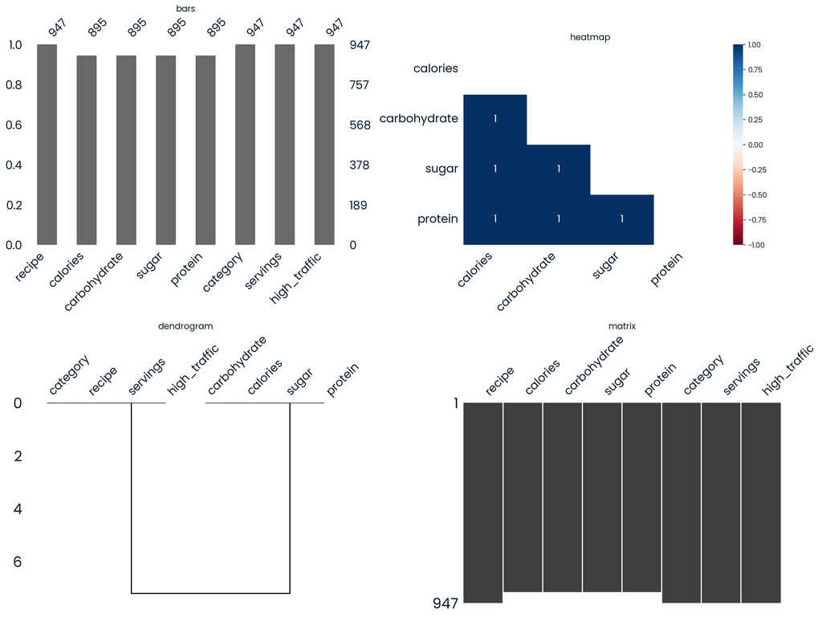

```python
fig, axes = plt.subplots(2, 2, figsize=(16, 12))

plt.sca(axes[0, 0])
msno.bar(df, ax=axes[0, 0])
axes[0, 0].set_title('bars')

plt.sca(axes[0, 1])
msno.heatmap(df, ax=axes[0, 1])
axes[0, 1].set_title('heatmap')

plt.sca(axes[1, 0])
msno.dendrogram(df, ax=axes[1, 0])
axes[1, 0].set_title('dendrogram')

plt.sca(axes[1, 1])
msno.matrix(df.sort_values('calories'), ax=axes[1, 1])
axes[1, 1].set_title('matrix')

plt.tight_layout()
plt.show()
```

**OBSERVATION** : for each row, if one of the values contained in the set of categories A = ('calories', 'carbohydrate', 'sugar', 'protein') is missing, then all other values of A are missing.

**INTERPRETATION** : Our missing data is correlated to other missing data.

### 1.B.2 Relations between missing data and observed data

#### 1.B.2.a Relation between missing data & 'category'

We can check for the absolute amount of missing data per category :

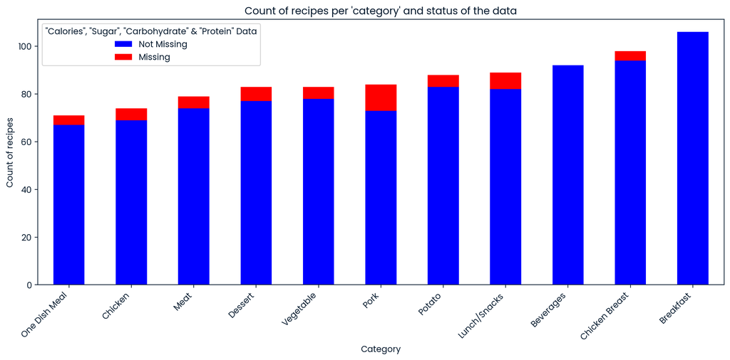

```python
df['missing_data'] = df['calories'].isnull()

stacked_data = pd.crosstab(df['category'], df['missing_data'])
stacked_data.columns = ['Not Missing', 'Missing']
stacked_data['Total'] = stacked_data['Not Missing'] + stacked_data['Missing']
stacked_data = stacked_data.sort_values(by='Total', ascending=True).drop(columns='Total')

stacked_data.plot(kind='bar', stacked=True, figsize=(12, 6), colormap='bwr')

plt.title("Count of recipes per 'category' and status of the data")
plt.xlabel("Category")
plt.ylabel("Count of recipes")
plt.xticks(rotation=45, ha='right')
plt.legend(title='"Calories", "Sugar", "Carbohydrate" & "Protein" Data')
plt.tight_layout()
plt.show()
```

Then, we can check for the relative amount of missing data per category :

```python
df.groupby("category").apply(lambda group: group.isna().mean() * 100)
```

| category | recipe | calories | carbohydrate | sugar | protein | category | servings | high_traffic | missing_data |
| --- | --- | --- | --- | --- | --- | --- | --- | --- | --- |
| Beverages | 0.0 | 0.000000 | 0.000000 | 0.000000 | 0.000000 | 0.0 | 0.0 | 0.0 | 0.0 |
| Breakfast | 0.0 | 0.000000 | 0.000000 | 0.000000 | 0.000000 | 0.0 | 0.0 | 0.0 | 0.0 |
| Chicken | 0.0 | 6.756757 | 6.756757 | 6.756757 | 6.756757 | 0.0 | 0.0 | 0.0 | 0.0 |
| Chicken Breast | 0.0 | 4.081633 | 4.081633 | 4.081633 | 4.081633 | 0.0 | 0.0 | 0.0 | 0.0 |
| Dessert | 0.0 | 7.228916 | 7.228916 | 7.228916 | 7.228916 | 0.0 | 0.0 | 0.0 | 0.0 |
| Lunch/Snacks | 0.0 | 7.865169 | 7.865169 | 7.865169 | 7.865169 | 0.0 | 0.0 | 0.0 | 0.0 |
| Meat | 0.0 | 6.329114 | 6.329114 | 6.329114 | 6.329114 | 0.0 | 0.0 | 0.0 | 0.0 |
| One Dish Meal | 0.0 | 5.633803 | 5.633803 | 5.633803 | 5.633803 | 0.0 | 0.0 | 0.0 | 0.0 |
| Pork | 0.0 | 13.095238 | 13.095238 | 13.095238 | 13.095238 | 0.0 | 0.0 | 0.0 | 0.0 |
| Potato | 0.0 | 5.681818 | 5.681818 | 5.681818 | 5.681818 | 0.0 | 0.0 | 0.0 | 0.0 |
| Vegetable | 0.0 | 6.024096 | 6.024096 | 6.024096 | 6.024096 | 0.0 | 0.0 | 0.0 | 0.0 |

**OBSERVATION** : The 'Pork' category is relatively missing a lot more information than the other categories, while 'Beverages' & 'Breakfast' don't have a single missing value.

We will now test the correlation between the 'category' and the missingness of 'calories' (which is the same as 'sugar', 'carbohydrate' & 'protein') via a contingency table. This table returns a chi-square statistic, p-value, degrees of freedom and an array of non-missing values that would be expected if 'category' and the missing values from 'calories' were independent (that is, the null hypothesis)

```python
# Testing correlation between two categorical variables : 'category' (type : category) & missing values from 'calories' (type : bool, missing or not)
contingency_table = pd.crosstab(df['category'], df['calories'].isnull())
chi2_contingency(contingency_table)
```

```
(23.07822497512879,
 0.010461490706555662,
 10,
 array([[ 86.94825766,   5.05174234],
        [100.17951426,   5.82048574],
        [ 69.93664203,   4.06335797],
        [ 92.6187962 ,   5.3812038 ],
        [ 78.44244984,   4.55755016],
        [ 84.11298838,   4.88701162],
        [ 74.66209081,   4.33790919],
        [ 67.10137276,   3.89862724],
        [ 79.3875396 ,   4.6124604 ],
        [ 83.16789863,   4.83210137],
        [ 78.44244984,   4.55755016]]))
```

**OBSERVATION** : p-value = 0.0105

**INTERPRETATION** : The missingness of 'calories', 'sugar', 'protein' & 'carbohydrate' MIGHT BE correlated to the values observed in the 'category' column, depending on the alpha value (0.01 < alpha < 0.05)

#### 1.B.2.b Relation between missing data & 'servings'

We can also check for the absolute amount of missing data per amount of servings :

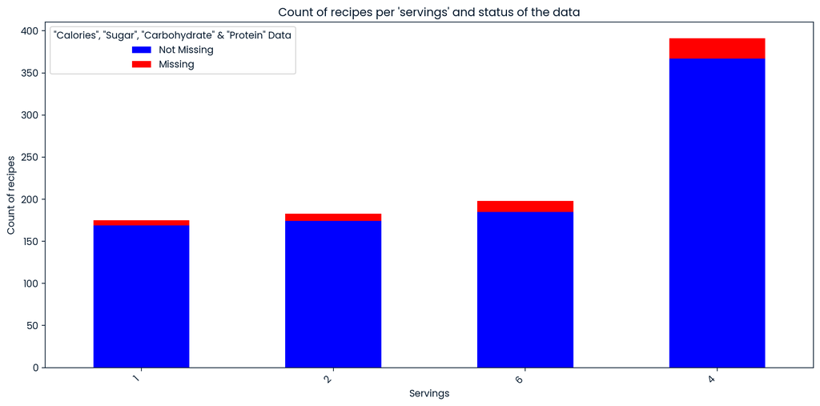

```python
stacked_data = pd.crosstab(df['servings'], df['missing_data'])
stacked_data.columns = ['Not Missing', 'Missing']
stacked_data['Total'] = stacked_data['Not Missing'] + stacked_data['Missing']
stacked_data = stacked_data.sort_values(by='Total', ascending=True).drop(columns='Total')

stacked_data.plot(kind='bar', stacked=True, figsize=(12, 6), colormap='bwr')

plt.title("Count of recipes per 'servings' and status of the data")
plt.xlabel("Servings")
plt.ylabel("Count of recipes")
plt.xticks(rotation=45, ha='right')
plt.legend(title='"Calories", "Sugar", "Carbohydrate" & "Protein" Data')
plt.tight_layout()
plt.show()
```

Then, we can check for the relative amount of missing data per servings :

```python
df.groupby("servings").apply(lambda group: group.isna().mean() * 100)
```

| servings | recipe | calories | carbohydrate | sugar | protein | category | servings | high_traffic | missing_data |
| --- | --- | --- | --- | --- | --- | --- | --- | --- | --- |
| 1 | 0.0 | 3.428571 | 3.428571 | 3.428571 | 3.428571 | 0.0 | 0.0 | 0.0 | 0.0 |
| 2 | 0.0 | 4.918033 | 4.918033 | 4.918033 | 4.918033 | 0.0 | 0.0 | 0.0 | 0.0 |
| 4 | 0.0 | 6.138107 | 6.138107 | 6.138107 | 6.138107 | 0.0 | 0.0 | 0.0 | 0.0 |
| 6 | 0.0 | 6.565657 | 6.565657 | 6.565657 | 6.565657 | 0.0 | 0.0 | 0.0 | 0.0 |

And finally, the contingency table :

```python
# Testing correlation between a numeric discrete variable and a categorical variable : 'servings' (type : numeric discrete) & missing values from 'calories' (type : bool, missing or not)
contingency_table = pd.crosstab(df['servings'], df['calories'].isnull())
chi2_contingency(contingency_table)
```

```
(2.306301020398831,
 0.5113148736132382,
 3,
 array([[165.3907075 ,   9.6092925 ],
        [172.95142555,  10.04857445],
        [369.53009504,  21.46990496],
        [187.12777191,  10.87222809]]))
```

**OBSERVATION** : p-value = 0.511

**INTERPRETATION** : The missingness of 'calories', 'sugar', 'protein' & 'carbohydrate' is NOT correlated to the values observed in the 'servings' column

#### 1.B.2.c Relation between missing data & 'high_traffic' (target)

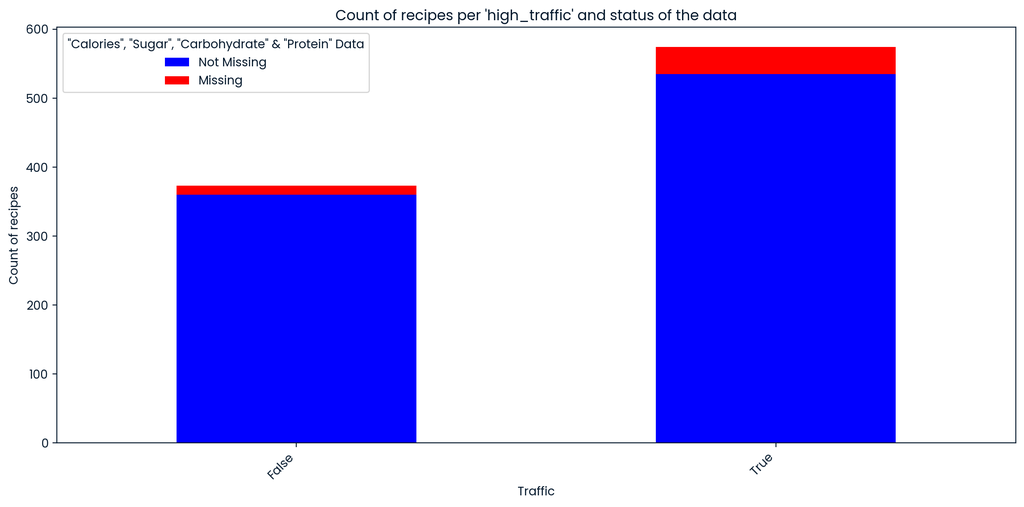

```python
stacked_data = pd.crosstab(df['high_traffic'], df['missing_data'])
stacked_data.columns = ['Not Missing', 'Missing']
stacked_data['Total'] = stacked_data['Not Missing'] + stacked_data['Missing']
stacked_data = stacked_data.sort_values(by='Total', ascending=True).drop(columns='Total')

stacked_data.plot(kind='bar', stacked=True, figsize=(12, 6), colormap='bwr')

plt.title("Count of recipes per 'high_traffic' and status of the data")
plt.xlabel("Traffic")
plt.ylabel("Count of recipes")
plt.xticks(rotation=45, ha='right')
plt.legend(title='"Calories", "Sugar", "Carbohydrate" & "Protein" Data')
plt.tight_layout()
plt.show()
```

We can also check for the relative amount of missing data per value of the target high_traffic :

```python
df.groupby("high_traffic").apply(lambda group: group.isna().mean() * 100)
```

| high_traffic | recipe | calories | carbohydrate | sugar | protein | category | servings | high_traffic | missing_data |
| --- | --- | --- | --- | --- | --- | --- | --- | --- | --- |
| False | 0.0 | 3.485255 | 3.485255 | 3.485255 | 3.485255 | 0.0 | 0.0 | 0.0 | 0.0 |
| True | 0.0 | 6.794425 | 6.794425 | 6.794425 | 6.794425 | 0.0 | 0.0 | 0.0 | 0.0 |

And the contingency table :

```python
# Testing correlation between a the target variable (categorical) and a categorical variable : 'high_traffic' (type : bool) & missing values from 'calories' (type : bool, missing or not)
contingency_table = pd.crosstab(df['high_traffic'], df['calories'].isnull())
chi2_contingency(contingency_table)
```

```
(4.154348065390012,
 0.041527757289053516,
 1,
 array([[352.51847941,  20.48152059],
        [542.48152059,  31.51847941]]))
```

**OBSERVATION** : p-value = 0.0416

**INTERPRETATION** : The missingness of 'calories', 'sugar', 'protein' & 'carbohydrate' can be correlated to the values observed in the 'high_traffic' column, depending on the alpha value (0.01 < alpha < 0.05)

#### 1.B.2.d Relation between missing data and observed data from 'calories', 'sugar', 'protein' & 'carbohydrate'

No observation can be made as we don't have any row containing missing data in 'calories' (for example) with observed values in the others : 'sugar', 'protein' & 'carbohydrate'

### 1.B.3 Conclusion about missing data relations

- Our missing data is 100% correlated to other missing data
- The missingness of 'calories', 'sugar', 'protein' & 'carbohydrate' MIGHT BE correlated to the values observed in the 'category' column, depending on the alpha value (0.01 < alpha < 0.05)
- The missingness of 'calories', 'sugar', 'protein' & 'carbohydrate' is NOT correlated to the values observed in the 'servings' column
- The missingness of 'calories', 'sugar', 'protein' & 'carbohydrate' MIGHT BE correlated to the values observed in the 'high_traffic' column, depending on the alpha value (0.01 < alpha < 0.05)

**CONCLUSION** :

- Our data is MNAR, as its missingness is correlated to observed & missing values, especially the latter.
- The fact that when 'carbohydrate', 'sugar' or 'protein' is missing, 'calories' is also missing makes some sense, since 'calories' is a function of these variables. But why don't we have rows with only two missing values ('calories' & 'carbohydrate' OR 'calories' & 'sugar' OR 'calories' & 'protein') then ? That alone makes the missingness very questionable.
- My hypothesis is that all the nutritional values were hidden when the amount of calories (or sugar or carbohydrate or protein) was judged "too high" by the person uploading the recipe, which would make sense, since a lot of customers are looking for low-cal or low-sugar meals.

### 1.B.4 Missing data imputations

The missing data might only be very high amounts of calories or very low amounts, we don't actually know. What we know is that these missing data have a significative probability of not behaving like a probabilistic distribution, ie missing data can be a very specific range of values.

We could include a lot of bias in our dataset by replacing it with the Median, but we are going to try and compare it with a KNNImputer.

Remark : As EDA will show later, distributions are non-normal so mean-imputations are out of question.

```python
df['missing_calories'] = df['calories'].isna().astype(int)
```

#### 1.B.4.a Median-imputation by Category

We impute here with the median of each category. As EDA will show later, medians differ a lot from one category to another.

```python
cols_to_impute = ['calories', 'sugar', 'carbohydrate', 'protein']
```

```python
df_median_imputed = df.copy(deep=True)

for col in cols_to_impute:
    df_median_imputed[col] = df_median_imputed.groupby('category')[col].transform(
        lambda x: x.fillna(x.median())
    )

df_median_imputed.to_csv('df_median_imputed.csv', sep=";")
```

#### 1.B.4.b KNNImputer

K-Nearest Neighbors algorithms require prior encoding of categorical variables to work.

```python
df_knn_imputed = df.copy(deep=True).drop(columns='recipe')

categorical_cols = df_knn_imputed.select_dtypes(include=['object', 'category', 'bool']).columns

encoder = OrdinalEncoder()
df_knn_imputed[categorical_cols] = encoder.fit_transform(df_knn_imputed[categorical_cols])

knn_imputer = KNNImputer()

df_knn_imputed.iloc[:, :] = knn_imputer.fit_transform(df_knn_imputed)

df_knn_imputed.to_csv('df_knn_imputed.csv', sep=";")
```

#### 1.B.4.c Comparison Median vs KNN

We will plot both imputation methods along with a Kolmogorov-Smirnov test. This non-parametrical test can be used to test whether a sample came from a given reference probability distribution (one-sample K–S test), or to test whether two samples came from the same distribution (two-sample K–S test)

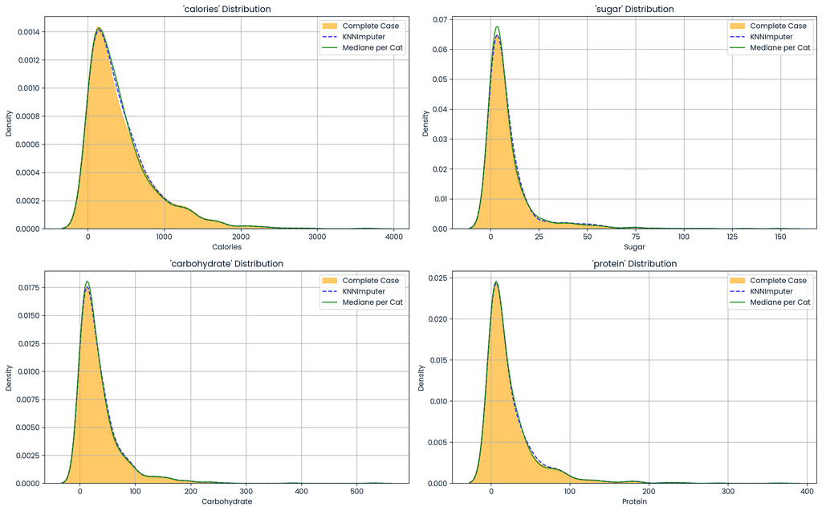

```python
fig, axes = plt.subplots(2, 2, figsize=(16, 10))
axes = axes.flatten()

for i, col in enumerate(cols_to_impute):
    ax = axes[i]

    sns.kdeplot(data=df.dropna(subset=[col]), x=col, label='Complete Case', fill=True, ax=ax, linestyle=':', color='orange', alpha=0.6)
    sns.kdeplot(data=df_knn_imputed, x=col, label='KNNImputer', fill=False, ax=ax, linestyle='--', color='blue', alpha=0.8)
    sns.kdeplot(data=df_median_imputed, x=col, label='Mediane per Cat', fill=False, ax=ax, linestyle='-', color='green', alpha=0.8)

    ax.set_title(f"'{col}' Distribution")
    ax.set_xlabel(col.capitalize())
    ax.grid(True)
    ax.legend()

plt.tight_layout()
plt.show()
```

```python
# Kolmogorov–Smirnov (KS)

group_0 = df['calories'].dropna()
group_1 = df_knn_imputed['calories']
group_2 = df_median_imputed['calories']

stat_knn, p_knn = ks_2samp(group_0, group_1)
print(f"KNN Imputation → stat = {stat_knn:.2f}, p-value = {p_knn:.4f}")

stat_median, p_median = ks_2samp(group_0, group_2)
print(f"Median per Category → stat = {stat_median:.2f}, p-value = {p_median:.4f}")
```

```
KNN Imputation → stat = 0.02, p-value = 0.9508
Median per Category → stat = 0.02, p-value = 0.9828
```

**OBSERVATIONS** :

- The apparent negative values are due to the kde smoothing curve, there were no negative calues in the original dataframe.
- Both imputations seem to follow the Complete Case very closely, maybe a little bit better for the KNN
- The Kolmogorov-Smirnov test shows that both post-imputation distributions can't be considered different from the Complete Case distribution

### 1.B.5 Conclusion about imputations

The *KNN imputation* will be kept for the rest of the project.

```python
df[cols_to_impute] = df_knn_imputed[cols_to_impute]

df.to_csv('df_validated.csv', sep=";")
```

# 2. Exploratory Data Analysis

Now that the missing data have been imputed, we can filter them :

```python
df = df[
    (df['calories'] > 0) &
    (df['carbohydrate'] > 0) &
    (df['sugar'] > 0) &
    (df['protein'] > 0)
]
```

## 2.A Numeric Continuous Nutritional Values

### Pre-Normalization of data

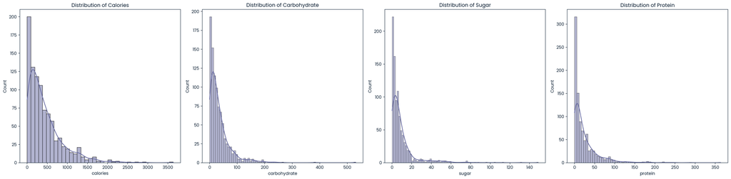

```python
fig, axes = plt.subplots(1, 4, figsize=(24, 6))

sns.histplot(data=df, x='calories', kde=True, ax=axes[0])
axes[0].set_title('Distribution of Calories')

sns.histplot(data=df, x='carbohydrate', kde=True, ax=axes[1])
axes[1].set_title('Distribution of Carbohydrate')

sns.histplot(data=df, x='sugar', kde=True, ax=axes[2])
axes[2].set_title('Distribution of Sugar')

sns.histplot(data=df, x='protein', kde=True, ax=axes[3])
axes[3].set_title('Distribution of Protein')

plt.tight_layout()
plt.show()
```

**OBSERVATIONS** : Data is not normal, long tail to the right, a test on my local notebook indicates Gamma functions (not enough resources here online)

### Post-Normalization of data (Box-Cox)

Normalizing and removing the outliers was not an easy task, as we had multiple categories with different medians. We tried treating outliers in the original distributions but the box-cox performance was impacted. We prefered to normalize first, then remove the outliers in our normalized space. This method impacts the extreme categories more than the balanced categories (ie, dessert have the highest sugars, so there is a risk that more of them will be removed, therefore introducing bias).

We selected 2 IQR instead of 1.5 IQR for this reason, letting the extreme catgories 'breathe' a little more.

Note : these normalized data won't be used for the rest of our EDA, but they will be useful for preprocessing data for Logistic Regresison.

```python
from sklearn.preprocessing import PowerTransformer

def remove_outliers_iqr_2bounds(df, columns):
    df_cleaned = df.copy()
    for col in columns:
        Q1 = df_cleaned[col].quantile(0.25)
        Q3 = df_cleaned[col].quantile(0.75)
        IQR = Q3 - Q1
        lower_bound = Q1 - 2 * IQR
        upper_bound = Q3 + 2 * IQR
        df_cleaned = df_cleaned[(df_cleaned[col] >= lower_bound) & (df_cleaned[col] <= upper_bound)]
    return df_cleaned

pt = PowerTransformer(method='box-cox', standardize=False)  # standardize=False = no automatic StandardScaler

normalized_df = df.copy(deep=True)
cols_to_transform = ['calories', 'sugar', 'carbohydrate', 'protein']

normalized_df[cols_to_transform] = pt.fit_transform(normalized_df[cols_to_transform])
normalized_df = remove_outliers_iqr_2bounds(normalized_df, cols_to_transform)
```

Visualization of the normalizing process

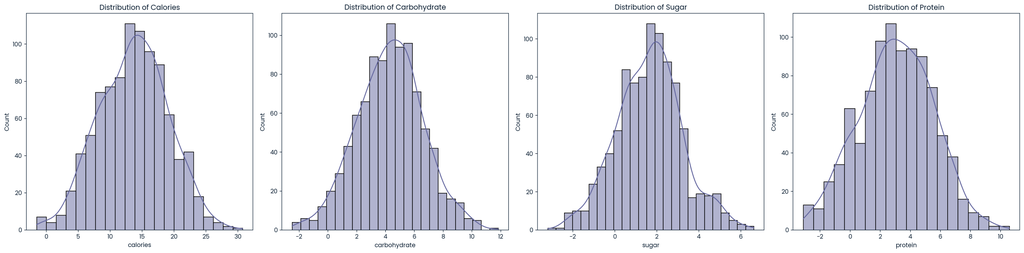

```python
fig, axes = plt.subplots(1, 4, figsize=(24, 6))

sns.histplot(data=normalized_df, x='calories', kde=True, ax=axes[0])
axes[0].set_title('Distribution of Calories')

sns.histplot(data=normalized_df, x='carbohydrate', kde=True, ax=axes[1])
axes[1].set_title('Distribution of Carbohydrate')

sns.histplot(data=normalized_df, x='sugar', kde=True, ax=axes[2])
axes[2].set_title('Distribution of Sugar')

sns.histplot(data=normalized_df, x='protein', kde=True, ax=axes[3])
axes[3].set_title('Distribution of Protein')

plt.tight_layout()
plt.show()
```

Scatterplot matrix for the normalized variables and correlation matrix

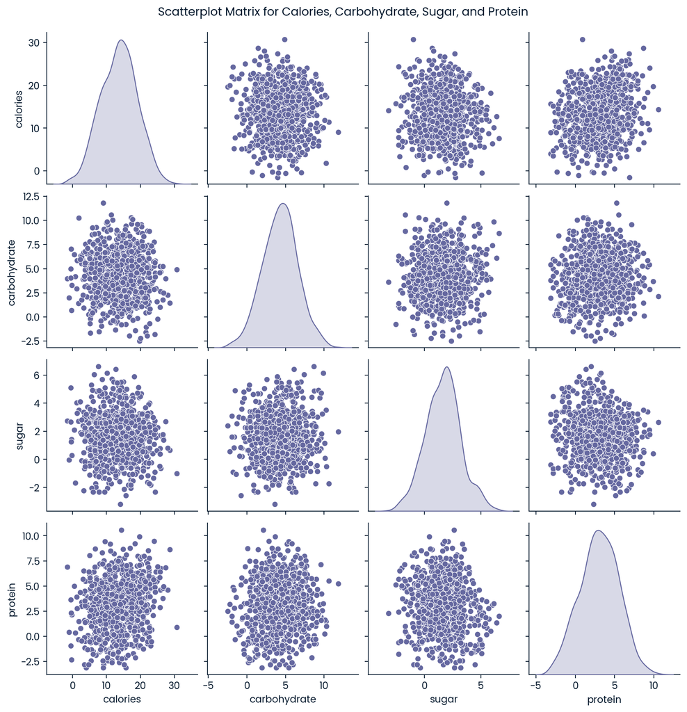

```python
sns.pairplot(normalized_df,
             diag_kind='kde',
             vars=['calories', 'carbohydrate', 'sugar', 'protein'])
plt.suptitle('Scatterplot Matrix for Calories, Carbohydrate, Sugar, and Protein', y=1.02)
plt.show()
```

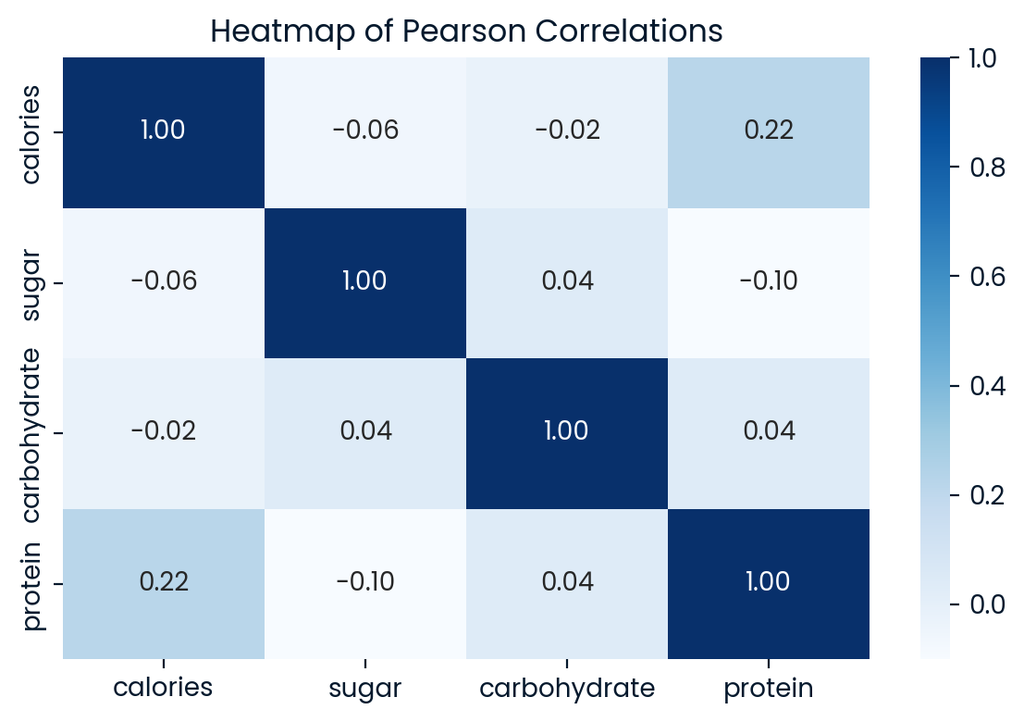

```python
correlation_matrix = normalized_df[['calories', 'sugar', 'carbohydrate', 'protein']].corr(method='pearson').round(2)
plt.figure(figsize=(6, 4))
sns.heatmap(correlation_matrix, annot=True, cmap="Blues", fmt=".2f")
plt.title("Heatmap of Pearson Correlations")
plt.tight_layout()
plt.show()
```

**OBSERVATIONS** : No correlation (except a small one between protein and calories)

**INTERPRETATION** : It's a bit surprising, but ok at least we don't have to remove any variable due to statistical dependence.

## 2.B Categorical 'Category' vs Nutritional Values

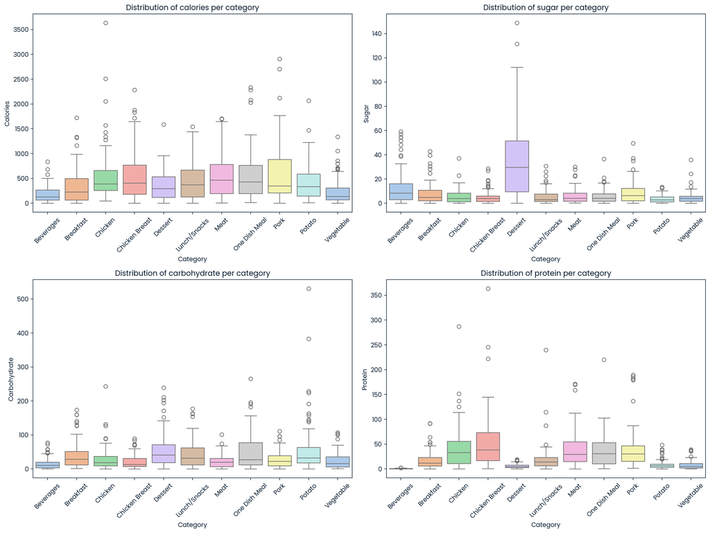

```python
fig, axes = plt.subplots(2, 2, figsize=(16, 12))

variables = ['calories', 'sugar', 'carbohydrate', 'protein']

for ax, var in zip(axes.flatten(), variables):
    sns.boxplot(x='category', y=var, data=df, palette='pastel', ax=ax)
    ax.set_title(f"Distribution of {var} per category")
    ax.set_xlabel("Category")
    ax.set_ylabel(var.capitalize())
    ax.tick_params(axis='x', rotation=45)

plt.tight_layout()
plt.show()
```

**OBSERVATIONS** :

- Categories are not well defined and contain a lot of "includes"-type of relationship, ie meat includes chicken includes chicken breast.
- Some categories have higher calory-rich recipes
- Dessert and beverages have the highest sugar
- Protein is linked to meats

**CONCLUSION** : Data globally makes sense, recipes tend to belong to the right category

## 2.C Categorical 'Servings' vs Nutritional Values

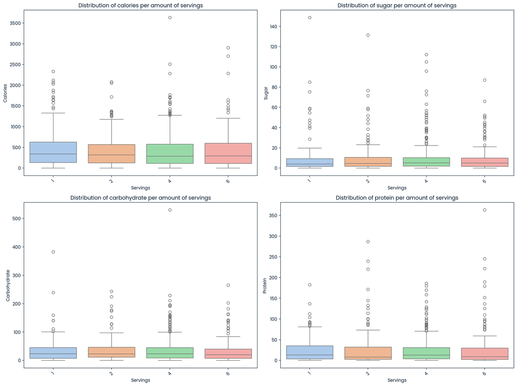

```python
fig, axes = plt.subplots(2, 2, figsize=(16, 12))

variables = ['calories', 'sugar', 'carbohydrate', 'protein']

for ax, var in zip(axes.flatten(), variables):
    sns.boxplot(x='servings', y=var, data=df, palette='pastel', ax=ax)
    ax.set_title(f"Distribution of {var} per amount of servings")
    ax.set_xlabel("Servings")
    ax.set_ylabel(var.capitalize())
    ax.tick_params(axis='x', rotation=45)

plt.tight_layout()
plt.show()
```

**OBSERVATIONS** :

- All the distributions look equal for each amount of servings

**CONCLUSION** : The nutritional features are given per serving

## 2.D Target : Categorical 'High_traffic'

### 2.D.1 Versus Nutritional Values

We will compare first with non-normalized data, then with normalized-data.

#### 2.D.1.a Versus Non-normalized data

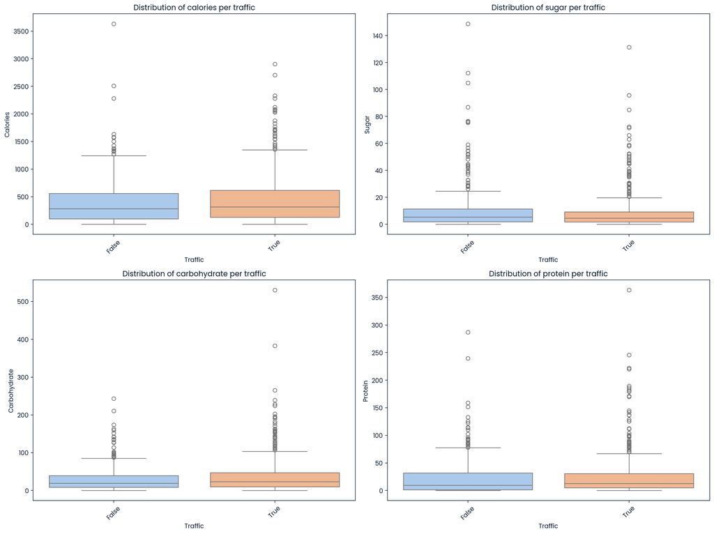

```python
fig, axes = plt.subplots(2, 2, figsize=(16, 12))

variables = ['calories', 'sugar', 'carbohydrate', 'protein']

for ax, var in zip(axes.flatten(), variables):
    sns.boxplot(x='high_traffic', y=var, data=df, palette='pastel', ax=ax)
    ax.set_title(f"Distribution of {var} per traffic")
    ax.set_xlabel("Traffic")
    ax.set_ylabel(var.capitalize())
    ax.tick_params(axis='x', rotation=45)

plt.tight_layout()
plt.show()
```

#### 2.D.1.b Versus Normalized data :

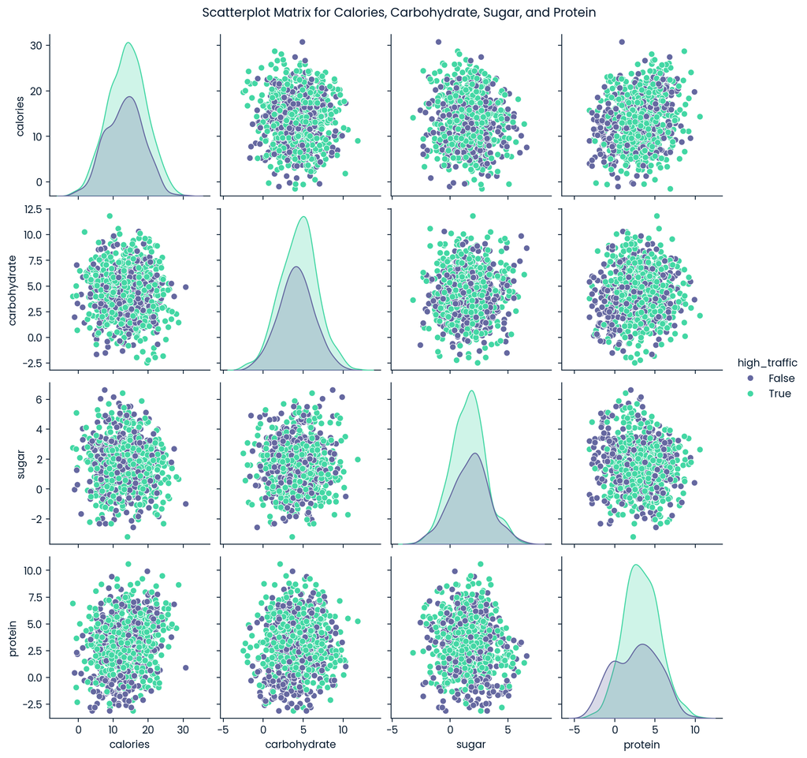

```python
sns.pairplot(normalized_df,
             diag_kind='kde',
             vars=['calories', 'carbohydrate', 'sugar', 'protein'],
             hue='high_traffic'
            )
plt.suptitle('Scatterplot Matrix for Calories, Carbohydrate, Sugar, and Protein', y=1.02)
plt.show()
```

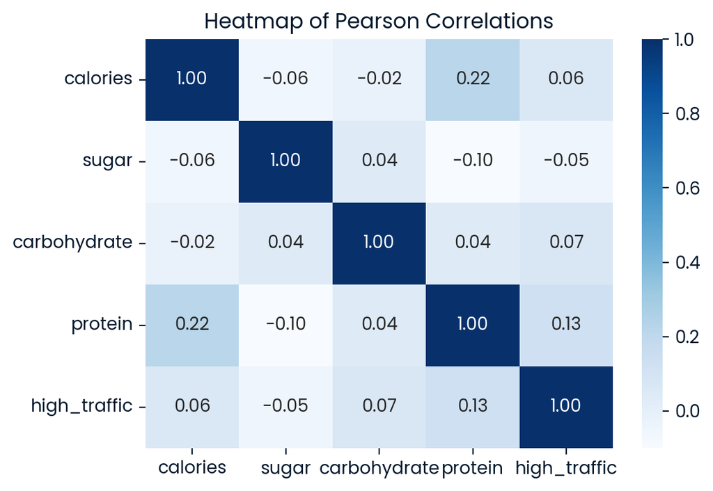

```python
correlation_matrix = normalized_df[['calories', 'sugar', 'carbohydrate', 'protein', 'high_traffic']].corr(method='pearson').round(2)
plt.figure(figsize=(6, 4))
sns.heatmap(correlation_matrix, annot=True, cmap="Blues", fmt=".2f")
plt.title("Heatmap of Pearson Correlations")
plt.tight_layout()
plt.show()
```

**OBSERVATIONS** :

- Higher calories, higher carbohydrates & higher proteins have higher traffic
- Lower Sugar has higher traffic

#### 2.D.1.c Conclusion

There are slight differences, but not significative. Categories will most likely be the most impactful, as we can already guess from the plurimodal curve 'protein' x 'protein' with 'high_traffic' = 'False'. These subpeaks come from the non homogenous probability of having a 'True' 'high_traffic' value among the differents categories.

### 2.D.2 Versus Servings & Category

#### 2.D.2.a Heatmaps & visual observations

We will create heatmaps of 'high_traffic' vs 'servings' & 'categories'

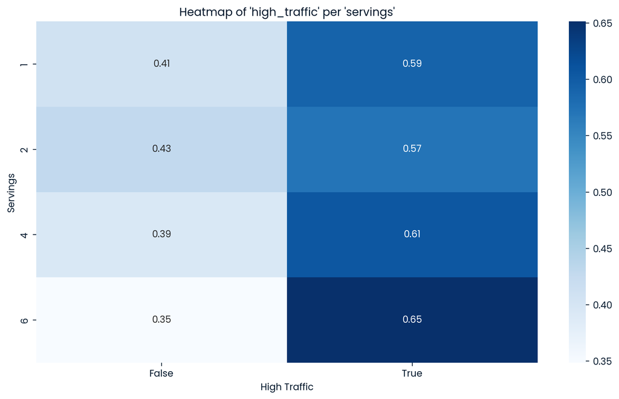

```python
plt.figure(figsize=(10, 6))

sns.heatmap(pd.crosstab(df['servings'], df['high_traffic'], normalize='index'),
            annot=True,
            cmap="Blues",
            fmt=".2f"
           )
plt.title("Heatmap of 'high_traffic' per 'servings'")
plt.xlabel("High Traffic")
plt.ylabel("Servings")
plt.tight_layout()
plt.show()
```

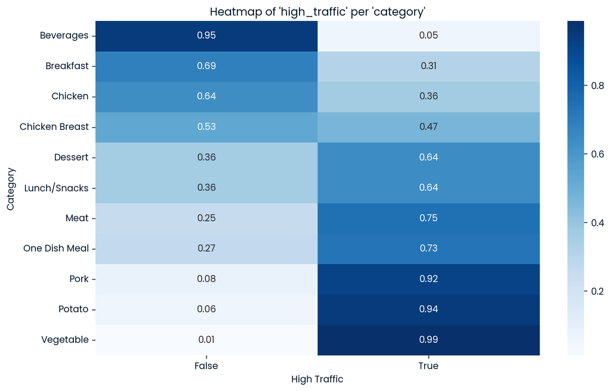

```python
plt.figure(figsize=(10, 6))
sns.heatmap(pd.crosstab(df['category'], df['high_traffic'], normalize='index'),
            annot=True,
            cmap="Blues",
            fmt=".2f"
           )
plt.title("Heatmap of 'high_traffic' per 'category'")
plt.xlabel("High Traffic")
plt.ylabel("Category")
plt.tight_layout()
plt.show()
```

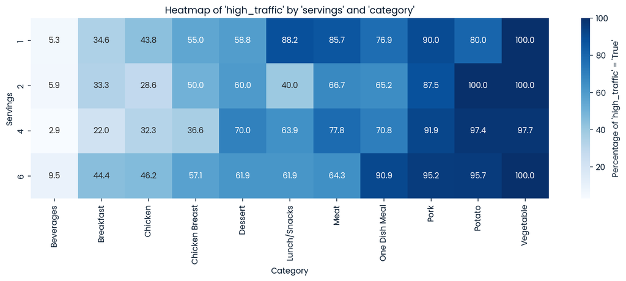

```python
heatmap_data = pd.crosstab(
    df['servings'],
    df['category'],
    values=df['high_traffic'],
    aggfunc='mean'
) * 100

plt.figure(figsize=(12, 5))
sns.heatmap(
    heatmap_data,
    annot=True,
    fmt=".1f",
    cmap="Blues",
    cbar_kws={"label": "Percentage of 'high_traffic' = 'True'"}
)
plt.title("Heatmap of 'high_traffic' by 'servings' and 'category'")
plt.xlabel("Category")
plt.ylabel("Servings")
plt.tight_layout()
plt.show()
```

**OBSERVATIONS** :

- Obviously, as expected, there is a huge correlation between the value of 'category' and 'high_traffic'
- There may be a weak correlation between 'servings' alone & 'high_traffic'.
- There is a correlation between 'servings' crossed with 'category' 'high_traffic'.

We will verify all these statements via statistical tests in the next part.

#### 2.D.2.b Chi-square tests

We will now make 3 independency chi² tests :

- Category vs High traffic
- Servings vs High traffic
- Category crossed to Servings vs High Traffic

```python
chi2, p_chi2, _, _ = chi2_contingency(pd.crosstab(df['category'], df['high_traffic']))
chi2_servings, p_chi2_servings, _, _ = chi2_contingency(pd.crosstab(df['servings'], df['high_traffic']))
chi2_combo, p_chi2_combo, _, _ = chi2_contingency(pd.crosstab(index=[df['category'], df['servings']], columns=df['high_traffic']))

# Summary
{
    "p-value Chi² (category vs high_traffic)": p_chi2,
    "p-value Chi² (servings vs high_traffic)": p_chi2_servings,
    "p-value Chi² (category+servings vs high_traffic)": p_chi2_combo
}
```

```
{'p-value Chi² (category vs high_traffic)': 2.2768227034572815e-62,
 'p-value Chi² (servings vs high_traffic)': 0.42793634557395843,
 'p-value Chi² (category+servings vs high_traffic)': 5.77994108914767e-48}
```

#### 2.D.2.c Conclusion

- There is no relation between Servings alone and High traffic
- There is a strong relation between Category and High traffic
- There is a strong relation between Category+Servings and High traffic

# 3. Model Development

What type of ML Algorithm will we go to ?

We want to predict a (binary) labeled category = CLASSIFICATION, we can then try :

- Logistic Regression as the baseline model
- Gradient Boosted Decision Tree as the comparison model

*Logistic Regression Preprocessing* :

Here are the restrictions for the Logistic Regression models :

- Encoding of categorical variables (One-Hot if few variables, Ordinal if many)
- Scaling of numerical variables (+ care for outliers)

*Gradient Boosted Decision Tree Preprocessing* :

Here are the restrictions for the GBDT models :

- Encoding of categorical variables (Ordinal is fine with trees)
- No scaling

## 3.A Preprocessing

```python
lr_X = normalized_df.drop(columns=["high_traffic", "recipe", "missing_calories"])
gbc_X = df.drop(columns=["high_traffic", "recipe", "missing_calories"])

lr_y = normalized_df["high_traffic"].astype(int) # yes, must do y as well cause we eliminated some rows in the normalized_df
gbc_y = df["high_traffic"].astype(int) # yes, must do y as well cause we eliminated some rows in the normalized_df

lr_X_train, lr_X_test, lr_y_train, lr_y_test = train_test_split(lr_X, lr_y, stratify=lr_y, test_size=0.2, random_state=42)
gbc_X_train, gbc_X_test, gbc_y_train, gbc_y_test = train_test_split(gbc_X, gbc_y, stratify=gbc_y, test_size=0.2, random_state=42)

num_cols = ['calories', 'carbohydrate', 'sugar', 'protein']
cat_cols = ['category', 'servings']

# LR
onehot_preprocessor = ColumnTransformer(transformers=[
    ('num', StandardScaler(), num_cols),
    ('cat', OneHotEncoder(handle_unknown='ignore'), cat_cols)
])

# GBC
ordinal_preprocessor = ColumnTransformer(transformers=[
    ('num', StandardScaler(), num_cols),
    ('cat', OrdinalEncoder(handle_unknown='use_encoded_value', unknown_value=-1), cat_cols)
])
```

## 3.B Base Model : Logistic Regression

### 3.B.1 Model training and hyperparameters tuning through GridSearchCV

We picked 'f1' as scoring since recall is at the expected value of 0.8, we decided to pick 'f1' as scoring as it is more balanced and gives higher ROC.

```python
lr_pipeline = Pipeline(steps=[
    ('preprocessor', onehot_preprocessor),
    ('classifier', LogisticRegression(max_iter=1000))
])

lr_param_grid = {
        'classifier': [LogisticRegression(max_iter=1000)],
        'classifier__C': [0.01, 0.1, 1, 10]
    }

lr_grid = GridSearchCV(lr_pipeline,
                    lr_param_grid,
                    cv=5,
                    scoring='f1', # since recall is at the expected value of 0.8, we decided to pick 'f1' as scoring as it is more balanced and gives higher ROC
                    n_jobs=-1)

lr_grid.fit(lr_X_train, lr_y_train)

lr_y_pred = lr_grid.predict(lr_X_test)
print("Meilleur modèle trouvé :", lr_grid.best_estimator_)
print("Score validation croisée :", lr_grid.best_score_)
lr_report = classification_report(lr_y_test, lr_y_pred)
print(lr_report)
```

```
Meilleur modèle trouvé : Pipeline(steps=[('preprocessor',
                 ColumnTransformer(transformers=[('num', StandardScaler(),
                                                  ['calories', 'carbohydrate',
                                                   'sugar', 'protein']),
                                                 ('cat',
                                                  OneHotEncoder(handle_unknown='ignore'),
                                                  ['category', 'servings'])])),
                ('classifier', LogisticRegression(C=0.1, max_iter=1000))])
Score validation croisée : 0.8012261480898266
              precision    recall  f1-score   support

           0       0.75      0.66      0.71        74
           1       0.80      0.86      0.83       115

    accuracy                           0.78       189
   macro avg       0.78      0.76      0.77       189
weighted avg       0.78      0.78      0.78       189
```

### 3.B.2 Best model's coefficients

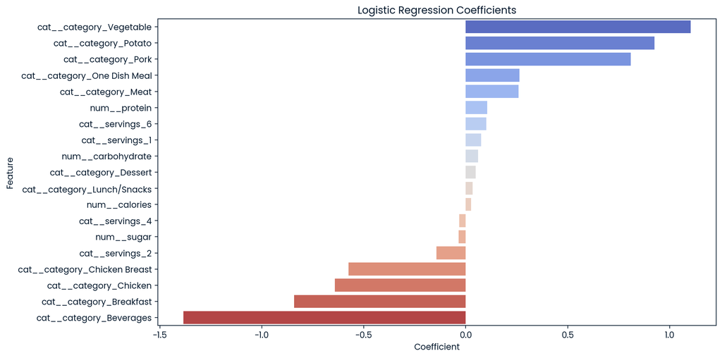

```python
best_lr_model = lr_grid.best_estimator_
lr_model = best_lr_model.named_steps['classifier']
feature_names = best_lr_model.named_steps['preprocessor'].get_feature_names_out()

coefficients = pd.DataFrame({
    'Feature': feature_names,
    'Coefficient': lr_model.coef_[0]
}).sort_values(by='Coefficient', ascending=False)

plt.figure(figsize=(12, 6))
sns.barplot(data=coefficients, x='Coefficient', y='Feature', palette='coolwarm')
plt.title("Logistic Regression Coefficients")
plt.tight_layout()
plt.show()
```

## 3.C Comparison Model : Gradient Boost Classifier

### 3.C.1 Model training and hyperparameters tuning through GridSearchCV

```python
gbc_pipeline = Pipeline(steps=[
    ('preprocessor', ordinal_preprocessor),
    ('classifier', GradientBoostingClassifier())
])

gbc_param_grid =  {
        'classifier': [GradientBoostingClassifier()],
        'classifier__n_estimators': [50, 100],
        'classifier__learning_rate': [0.01, 0.1, 0.5]
    }

gbc_grid = GridSearchCV(gbc_pipeline,
                    gbc_param_grid,
                    cv=5,
                    scoring='f1', # since recall is at the expected value of 0.8, we decided to pick 'f1' as scoring
                    n_jobs=-1)

gbc_grid.fit(X_train, y_train)

gbc_y_pred = gbc_grid.predict(X_test)
gbc_report = classification_report(y_test, gbc_y_pred)
print("Meilleur modèle trouvé :", gbc_grid.best_estimator_)
print("Score validation croisée :", gbc_grid.best_score_)
print(gbc_report)
```

```
Meilleur modèle trouvé : Pipeline(steps=[('preprocessor',
                 ColumnTransformer(transformers=[('num', StandardScaler(),
                                                  ['calories', 'carbohydrate',
                                                   'sugar', 'protein']),
                                                 ('cat',
                                                  OrdinalEncoder(handle_unknown='use_encoded_value',
                                                                 unknown_value=-1),
                                                  ['category', 'servings'])])),
                ('classifier', GradientBoostingClassifier(learning_rate=0.01))])
Score validation croisée : 0.8028985272627779
              precision    recall  f1-score   support

           0       0.68      0.68      0.68        74
           1       0.79      0.79      0.79       115

    accuracy                           0.75       189
   macro avg       0.73      0.73      0.73       189
weighted avg       0.75      0.75      0.75       189
```

# 4. Model Evaluation

## 4.A Confusion Matrices

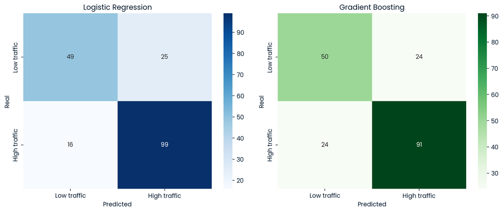

```
Logistic Regression :
              precision    recall  f1-score   support

           0       0.75      0.66      0.71        74
           1       0.80      0.86      0.83       115

    accuracy                           0.78       189
   macro avg       0.78      0.76      0.77       189
weighted avg       0.78      0.78      0.78       189

Gradient Boosting :
              precision    recall  f1-score   support

           0       0.68      0.68      0.68        74
           1       0.79      0.79      0.79       115

    accuracy                           0.75       189
   macro avg       0.73      0.73      0.73       189
weighted avg       0.75      0.75      0.75       189
```

```python
lr_conf_matrix = confusion_matrix(lr_y_test, lr_y_pred)
gbc_conf_matrix = confusion_matrix(gbc_y_test, gbc_y_pred)

fig, axes = plt.subplots(1, 2, figsize=(12, 5))

# Logistic Regression
sns.heatmap(lr_conf_matrix, annot=True, fmt='d', cmap='Blues', ax=axes[0],
            xticklabels=['Low traffic', 'High traffic'],
            yticklabels=['Low traffic', 'High traffic'])
axes[0].set_title("Logistic Regression")
axes[0].set_xlabel("Predicted")
axes[0].set_ylabel("Real")

# Gradient Boosting
sns.heatmap(gbc_conf_matrix, annot=True, fmt='d', cmap='Greens', ax=axes[1],
            xticklabels=['Low traffic', 'High traffic'],
            yticklabels=['Low traffic', 'High traffic'])
axes[1].set_title("Gradient Boosting")
axes[1].set_xlabel("Predicted")
axes[1].set_ylabel("Real")

plt.tight_layout()
plt.show()
print(f'Logistic Regression : \n{lr_report}')
print(f'Gradient Boosting : \n{gbc_report}')
```

## 4.B ROC Curves

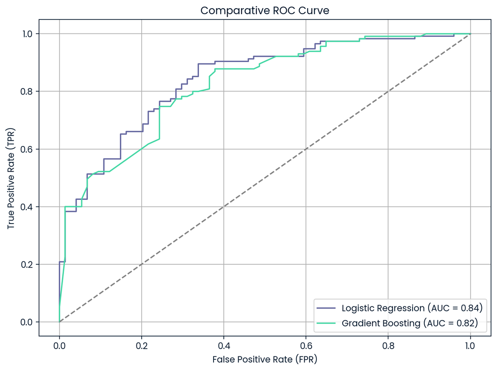

```python
lr_probs = lr_grid.predict_proba(lr_X_test)[:, 1]
gbc_probs = gbc_grid.predict_proba(gbc_X_test)[:, 1]

lr_fpr, lr_tpr, _ = roc_curve(lr_y_test, lr_probs)
gbc_fpr, gbc_tpr, _ = roc_curve(gbc_y_test, gbc_probs)

lr_auc = roc_auc_score(lr_y_test, lr_probs)
gbc_auc = roc_auc_score(gbc_y_test, gbc_probs)

plt.figure(figsize=(8, 6))
plt.plot(lr_fpr, lr_tpr, label=f'Logistic Regression (AUC = {lr_auc:.2f})')
plt.plot(gbc_fpr, gbc_tpr, label=f'Gradient Boosting (AUC = {gbc_auc:.2f})')
plt.plot([0, 1], [0, 1], linestyle='--', color='gray')  # Baseline
plt.title('Comparative ROC Curve')
plt.xlabel('False Positive Rate (FPR)') # proportion of negative cases incorrectly predicted as positive
plt.ylabel('True Positive Rate (TPR)') # proportion of positive cases correctly predicted as positive
plt.legend(loc='lower right')
plt.grid(True)
plt.tight_layout()
plt.show()
```

**OBSERVATIONS & INTERPRETATION** :

Both models achieved an AUC > 0.8, demonstrating strong ability to distinguish between popular and unpopular recipes. Logistic Regression is the better model : higher AUC and its curve arcs more than the Gradient Boost curve.

## 4.C Conclusion

Logistic regression is recommended for its better classification ability, simplicity, efficiency, and ease of interpretation by stakeholders (coefficients can be processed).

# 5. Metric & Monitoring

Based on the initial instructions : "Predict which recipes will be popular 80% of the time and minimize the chance of showing unpopular recipes." :

- "Predict which recipes will be popular 80% of the time..." = to maximize recall
- "...minimize the chance of showing unpopular recipes." = to maximize precision

To handle both requirements, I'd suggest monitoring *f1*. If precision or recall drop significately, then f1 will drop as well.

# 6. Summary & Recommendations

In this project, we aimed to predict which recipes would be popular with at least 80% 'accuracy' while minimizing the risk of recommending unpopular recipes.

- Data cleaning :
  - Removing errors
  - Applying the right types to each variable
- Handling of missing data :
  - Diagnostic : MNAR data
  - Proposition : Median-per-category vs KNN Imputations
  - Conclusion : KNN Imputation was kept
- Exploratory Data Analysis : we decided to treat 'Servings' as a categorical variable, since it doesn't make a lot of sense to treat it as numerical.
  - Numeric Continuous Nutritional Values : Extremely-skewed non-normal distributions, they have been normalized to show correlations (no correlations in between them) and for further Logistic Regression
  - Categorical 'Category' vs Nutritional Values : shows that the recipes make sense, ie meats have more proteins, desserts have more sugars...
  - Categorical 'Servings' vs Nutritional Values : shows that the nutritional values are given per serving.
  - Target Categorical 'High_traffic' vs Nutritional Values : Higher calories, higher carbohydrates & higher proteins have higher traffic, Lower Sugar has higher traffic. No significative differences.
  - Target Categorical 'High_traffic' vs 'Servings' & 'Category' :
    - There is no relation between Servings alone and High traffic
    - There is a strong relation between Category and High traffic
    - There is a strong relation between Category+Servings and High traffic
- After testing and evaluating two classification models with their respective hyperparameters, we found out that both Logistic Regression and Gradient Boosting performed well in terms of classification metrics. However, Logistic Regression performed better in terms of recall and precision and has been picked for this reason as the model to be pushed in production towards the ML Engineering team. The chosen metric is the f1-score for 'high_traffic' = True. Its starting value is 0.83.
- Improvements can be made for the tuning of the hyperparameters of Gradient Boost. When 'recall' is picked as scoring parameter, it can be extremely high but at the cost of a lot of false positive. We think that there must be an 'in-between' case where recall could be superior to 0.85 (or maybe 0.9), without increasing the risk of showing low-traffic recipes by too much. Working on the missing data and its root causes (as it is MNAR) can also be helpful.

## ✅ When you have finished...

- Publish your Workspace using the option on the left
- Check the published version of your report:
  - Can you see everything you want us to grade?
  - Are all the graphics visible?
- Review the grading rubric. Have you included everything that will be graded?
- Head back to the [Certification Dashboard](https://app.datacamp.com/certification) to submit your practical exam report and record your presentation